# Analysis of bikeshare data

Cameron Mitchell

11/6/2020

The goal of this analysis is to provide some prelimiary analysis on the bike share data for August 2020. I will be focusing on finding the deficits and gains for each of the bikestations

## Prepare workspace:

#### Load packages

We will work primarily within the context of the tidyverse set of packages, with a few additional packages supporting exploratory analysis. I have included the `lubridate` package, as we will want to do some work with dates.

```r
library(tidyverse)
library(janitor)
library(readxl)
library(skimr)
library(summarytools)
library(lubridate)
```

## Data

The orginal source of the data was the csv file

https://s3.amazonaws.com/capitalbikeshare-data/202008-capitalbikeshare-tripdata.zip

so I will use that original source data so that my research is more *reproducible*.

### Read the data

I read the original .csv file and add in the variables `duration`, `hour_of_day`, and `day_of_week`.

```r
dfa= read_csv("../Data/202008-capitalbikeshare-tripdata.csv") %>%
  clean_names() %>%
  mutate(duration=as.numeric((ended_at-started_at)/60),
         hour_of_day=hour(started_at),
         day_of_week=wday(started_at,label = T))
```

We summarize that dataframe to identify data types, missing data, et cetera.

```r
skim(dfa)
```

```
-- Data Summary ------------------------
                           Values
Name                       dfa
Number of rows             251543
Number of columns          16
_______________________
Column type frequency:
  character                5
  factor                   1
  numeric                  8
  POSIXct                  2
________________________
Group variables            None

-- Variable type: character ---------------------------------------
# A tibble: 5 x 8
  skim_variable      n_missing complete_rate   min   max empty
* <chr>                  <int>         <dbl> <int> <int> <int>
1 ride_id                    0         1        16    16     0
2 rideable_type              0         1        11    13     0
3 start_station_name     15880         0.937    10    61     0
4 end_station_name       18373         0.927    10    61     0
5 member_casual              0         1         6     6     0
  n_unique whitespace
*    <int>      <int>
1   251543          0
2        2          0
3      605          0
4      607          0
5        2          0

-- Variable type: factor ------------------------------------------
# A tibble: 1 x 6
  skim_variable n_missing complete_rate ordered n_unique
* <chr>             <int>         <dbl> <lgl>      <int>
1 day_of_week           0             1 TRUE           7
  top_counts
* <chr>
1 Sat: 51606, Sun: 48568, Fri: 35614, Wed: 30180

```

[output cut: 18 more lines]

```
5  38.9   38.9  38.9    39.3 ▁▇▁▁▁
6 -77.0  -77.0 -77.0   -76.6 ▁▁▇▁▁
7   8.27  15.1  26.4 36978.  ▇▁▁▁▁
8  11     15    18      23   ▁▂▅▇▅

-- Variable type: POSIXct -----------------------------------------
# A tibble: 2 x 7
  skim_variable n_missing complete_rate min
* <chr>             <int>         <dbl> <dttm>
1 started_at            0             1 2020-08-01 00:00:23
2 ended_at              0             1 2020-08-01 00:06:32
  max                 median              n_unique
* <dttm>              <dttm>                 <int>
1 2020-08-31 23:56:58 2020-08-17 05:20:58   232447
2 2020-09-03 13:35:08 2020-08-17 06:10:12   231289
```

#### A histogram - like we did in class

As we discussed in class, we might be interested in looking at histogram of durations, broken out for each day of the week. Here I filter to positive duration shorter than 100 minutes.

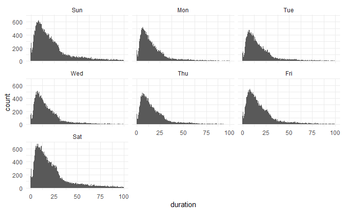

```r
dfa %>% filter(duration<100,duration>0) %>%
  ggplot(aes(x=duration)) + geom_histogram(bins = 300)+facet_wrap(~day_of_week)
```

### Cleaning

Limit to durations that are positive.

```r
dfb=dfa %>% filter(duration>0)


dfe = dfb %>%
  pivot_longer(started_at:ended_at, names_to="type",values_to="t") %>% arrange(t) %>%
  mutate(increment=case_when(
   type=="start_date"~1,
   type=="end_date" ~ -1)) %>%
  mutate(riders=cumsum(increment))
```

### This section will be used to determine the number of bikes gained or lost at each bike station.

```r
# number of starts at each station
dfstart = dfb %>% group_by(station = start_station_id) %>%
  summarise(start_num = n())
# number of ends at each station
dfend = dfb %>% group_by(station = end_station_id) %>%
  summarise(end_num = n())
# joining the two dataframes with all the valid data and computing the net gain
dfc = merge(dfstart, dfend) %>%
  filter(!is.na(station)) %>%
  mutate(net_gain = start_num - end_num)
```

The code below is just another way of getting a similar dataframe that I might want.

```r
dfriders = dfb %>%
  pivot_longer(started_at:ended_at, names_to="type",values_to="t") %>% arrange(t) %>%
  mutate(increment=case_when(
   type=="start_date"~1,
   type=="end_date" ~ -1)) %>%
  mutate(riders=cumsum(increment)) %>%
  group_by(station = start_station_id) %>%
  summarise(start_num = n())
```

### Visualization

Using ggplot2 I will try to show some of the results

```r
dfc %>% ggplot(aes(x = net_gain)) + geom_histogram()
```

[output not shown]